# 在线旅游产品销售分析

沈雨薇 2016200620

2019-01-10

## 数据初步分析与整理

在查看数据集信息，除去三个月成交量的因变量之后，思考一般人去旅游的流程：

- 首先是筛选阶段，一般人都选择在时间有限的公共假期或者年休假进行出游，因此会先确定旅游的大概时间和预算budget，以及出行的目的地和出行的方式（自助游、半自助游）等。
- 第二阶段是货比三家阶段，在第一阶段筛选出来的项目中仔细比较产品特色、套餐所含内容以及景点等信息，在对产品观感差不多的情况下，选择性价比最高的产品或者选择用户反馈最好、商家信用评级最高的产品。

因此，可以将自变量可以分成以下几类:

- 产品筛选变量
  - 因子型，旅游类型
  - 因子型，目的地
  - 因子型，景点个数
  - 因子型，行程长度
  - 字符型，度假项目主标题
- 产品比较变量
  - 字符型，套餐
  - 字符型，产品特色
- 商家信息变量：
  - 字符型，商家名称
  - 因子型或者数量型，信用评级
  - 服务承诺
- 价格驱动变量：
  - 字符型，活动信息
  - 数量型，价格
- 用户反馈变量：
  - 数量型，满意度
  - 数量型，评论数
  - 数量型，商家评级

值得注意的是：由于datalist中的商家全部为BearTrip认证商家，可以认为信用都比较好，因此信用是否有用尚待验证

```r
rm(list=ls())
dat<-read.csv('dat.csv')
summary(dat) #查看数据集信息
```

```
##   三个月成交量
##  Min.   :  0.00
##  1st Qu.: 23.00
##  Median : 26.00
##  Mean   : 29.56
##  3rd Qu.: 29.00
##  Max.   :946.00
##
##                                                                                                                                                                                                                                                                                                          …
##  券:使用代金券，可享受立减优惠（不可与本网其他优惠活动同时使用，保险订单金额不参与优惠活动）|礼品卡:可使用礼品卡|支付返券:支付满60元（不含保险/搭售产品/快递等费用），到订单列表找到“分享返券”按钮将礼包转发到微博，可领取最高500元的可找零度假代金券。支付成功后30天内可领取|专享红包:使用专享红包，可享受立减优惠:（不可与本网其他优惠活动同时使用，保险订单金额不参与优惠活动）|现金红包:使用现金红包，可享受立减优惠:（不可与本网其他优惠活动同时使用，保险订单金额不参与优惠活动）                                                  …
##  券:使用代金券，可享受立减优惠（不可与本网其他优惠活动同时使用，保险订单金额不参与优惠活动）|支付返券:支付满60元（不含保险/搭售产品/快递等费用），到订单列表找到“分享返券”按钮将礼包转发到微博，可领取最高500元的可找零度假代金券。支付成功后30天内可领取|专享红包:使用专享红包，可享受立减优惠:（不可与本网其他优惠活动同时使用，保险订单金额不参与优惠活动）|现金红包:使用现金红包，可享受立减优惠:（不可与本网其他优惠活动同时使用，保险订单金额不参与优惠活动）                                                             …
##  券:使用代金券，可享受立减优惠（不可与本网其他优惠活动同时使用，保险订单金额不参与优惠活动）|礼品卡:可使用礼品卡|支付返券:支付满60元（不含保险/搭售产品/快递等费用），到订单列表找到“分享返券”按钮将礼包转发到微博，可领取最高500元的可找零度假代金券。支付成功后30天内可领取|专享红包:使用专享红包，可享受立减优惠:（不可与本网其他优惠活动同时使用，保险订单金额不参与优惠活动）|现金红包:使用现金红包，可享受立减优惠:（不可与本网其他优惠活动同时使用，保险订单金额不参与优惠活动）|会员价                                              …
##  券:使用代金券，可享受立减优惠（不可与本网其他优惠活动同时使用，保险订单金额不参与优惠活动）|礼品卡:可使用礼品卡|支付返券:支付满60元（不含保险/搭售产品/快递等费用），到订单列表找到“分享返券”按钮将礼包转发到微博，可领取最高500元的可找零度假代金券。支付成功后30天内可领取|多人立减:活动有效期：2016年12月01日-2016年12月31日:减免明细: 双人出行减免100元|专享红包:使用专享红包，可享受立减优惠:（不可与本网其他优惠活动同时使用，保险订单金额不参与优惠活动）|现金红包:使用现金红包，可享受立减优惠:（不可与本网其他优惠活动同时使用，保险订单金额不参与优惠活…
##  券:使用代金券，可享受立减优惠（不可与本网其他优惠活动同时使用，保险订单金额不参与优惠活动）|礼品卡:可使用礼品卡|支付返券:支付满60元（不含保险/搭售产品/快递等费用），到订单列表找到“分享返券”按钮将礼包转发到微博，可领取最高500元的可找零度假代金券。支付成功后30天内可领取|多人立减:活动有效期：2016年12月02日-2017年03月01日:减免明细: 双人出行减免300元|专享红包:使用专享红包，可享受立减优惠:（不可与本网其他优惠活动同时使用，保险订单金额不参与优惠活动）|现金红包:使用现金红包，可享受立减优惠:（不可与本网其他优惠活动同时使用，保险订单金额不参与优惠活…
##  券:使用代金券，可享受立减优惠（不可与本网其他优惠活动同时使用，保险订单金额不参与优惠活动）|礼品卡:可使用礼品卡|支付返券:支付满60元（不含保险/搭售产品/快递等费用），到订单列表找到“分享返券”按钮将礼包转发到微博，可领取最高500元的可找零度假代金券。支付成功后30天内可领取|多人立减:活动有效期：2016年09月02日-2016年12月31日:减免明细: 多人出行第2人减免10元|优惠信息:即刻起下单立减，五星好评再返现！申明：每单不可同时享受多个优惠活动，以全部优惠活动中的最高优惠来减免。|专享红包:使用专享红包，可享受立减优惠:（不可与本网其他优惠活动同时使用，保险订单金…
##  (Other)                                                                                                                                                                                                                                                                                                 …
##      满意度                                            商家名称
##  Min.   : 96.00   中国康辉旅游:BearTrip网认证商家          : 170
##  1st Qu.:100.00   中国旅行社有限责任公司:BearTrip网认证商家: 169
##  Median :100.00   世界风情:BearTrip网认证商家              : 110
##  Mean   : 99.83   驴妈妈旅游:BearTrip网认证商家            : 102
##  3rd Qu.:100.00   同道旅游:BearTrip网认证商家              :  84
##  Max.   :100.00   同道国旅:BearTrip网认证商家              :  70
##                   (Other)                                  :3661
##                                                                                度假项目主标题
##  【半自助游】任性5飞（5星温泉酒店+御食盛宴+视觉震撼）+雪山索道+野象谷｜昆大丽版深游   :   4
##  【跟团游】德国+捷克+斯洛伐克+匈牙利+奥地利+瑞士10日+全国多地出发 畅游东欧名城        :   4
##  【跟团游】美国东西海岸+纽约+华盛顿+洛杉矶+旧金山+夏威夷+尼亚加拉大瀑布16日           :   4
##  【跟团游】美国东西海岸+夏威夷+大提顿国家公园+尼亚加拉瀑布+加拿大东西海岸18日         :   4
##  【跟团游】【东方古都、长城故乡】北京出发—北京两日游（八达岭长城、故宫、天坛、颐和园）:   3
##  【跟团游】避寒暖冬☀四环飞→不走回头路→温馨年夜饭+春节儿童免团费昆大丽版纳8日游 :   3
##  (Other)                                                                              :4344
##       价格             商家评级      用户评价数量
##  Min.   :     7.0   Min.   :4.800   Min.   :   1.00
##  1st Qu.:   625.8   1st Qu.:5.000   1st Qu.:  24.00
##  Median :  2780.0   Median :5.000   Median :  27.00
##  Mean   :  7222.5   Mean   :4.993   Mean   :  38.38
##  3rd Qu.:  6853.2   3rd Qu.:5.000   3rd Qu.:  30.00
##  Max.   :252803.0   Max.   :5.000   Max.   :1966.00
##
```

[output cut: 25 more lines]

```
##  即时确认:本产品价格、团期等信息已经过核实，在您完成付款签约后，即可出游                  :3714
##  二次确认:本产品价格、团期等信息需供应商为您核实。核实有位后，在您完成付款签约后，即可出游: 546
##  直飞往返                                                                                 :  46
##  赠送意外险                                                                               :  14
##  赠送保险                                                                                 :   7
##  充分游玩时间                                                                             :   6
##  (Other)                                                                                  :  33
##         目的地           旅游类型    行程长度       景点个数
##  泰国      : 303   北京周边游: 510   短期:1508   unknown:1039
##  日本      : 291   东南亚    : 505   长期:1511   多     :1155
##  大理      : 288   东亚      : 291   中期:1347   少     :1182
##  八达岭长城: 265   港澳台    : 120               中     : 990
##  欧洲      : 263   国内游    :2037
##  深圳      : 257   美洲      : 426
##  (Other)   :2699   欧洲      : 477
```

```r
dat<-read.csv('dat.csv',stringsAsFactors = F,encoding='utf-8')#将字符型变量保持原状
```

## 生成衍生变量

### 活动优惠信息提取

注意到活动信息中有多个项目，故可以把活动信息分开.首先确认有多少种活动，然后把相应的活动信息按照种类分开，选择其中有效的信息新建变量（如果每条数据都包含了这个信息，则是无效信息，因为没有variance）。最终得到的变量有礼品卡、多人立减、优惠信息、专享红包、早订优惠、会员价。

对变量含义的解释

```
礼品卡：逻辑变量，TRUE代表可以使用礼品卡
多人立减：逻辑变量，TRUE代表可以多人立减
优惠信息：逻辑变量，TRUE代表可以好评返现
专享红包：逻辑变量，TRUE代表可以用专享红包
早订优惠：逻辑变量，TRUE代表早订可以优惠
会员价：逻辑变量，TRUE代表会员有优惠
```

```r
library(stringr)
n<-nrow(dat)
n #一共有几条数据
```

```
## [1] 4366
```

```r
##查看有多少种活动##
inf<- strsplit(dat$活动信息, "|", fixed = T)  # 使用'|'进行分割
infsum<-as.data.frame(table(unlist(inf))) #查看促销信息的种类
infsum[order(infsum$Freq,decreasing=TRUE),]#按照出现频率进行排序
```

```
##                                                                                                                                                            Var1
## 15                                                                  券:使用代金券，可享受立减优惠（不可与本网其他优惠活动同时使用，保险订单金额不参与优惠活动）
## 16                                                         现金红包:使用现金红包，可享受立减优惠:（不可与本网其他优惠活动同时使用，保险订单金额不参与优惠活动）
## 40 支付返券:支付满60元（不含保险/搭售产品/快递等费用），到订单列表找到“分享返券”按钮将礼包转发到微博，可领取最高500元的可找零度假代金券。支付成功后30天内可领取
## 41                                                         专享红包:使用专享红包，可享受立减优惠:（不可与本网其他优惠活动同时使用，保险订单金额不参与优惠活动）
## 14                                                                                                                                          礼品卡:可使用礼品卡
## 13                                                                                                                                                       会员价
## 6                                                                                多人立减:活动有效期：2016年12月01日-2016年12月31日:减免明细: 双人出行减免100元
## 9                                                                                多人立减:活动有效期：2016年12月02日-2017年03月01日:减免明细: 双人出行减免300元
## 1                                                                            多人立减:活动有效期：2016年09月02日-2016年12月31日:减免明细: 多人出行第2人减免10元
## 23                                              优惠信息:即刻起下单立减，五星好评再返现！申明：每单不可同时享受多个优惠活动，以全部优惠活动中的最高优惠来减免。
## 33                                          早订优惠:活动有效期：2016年09月03日-2016年12月31日:优惠明细: 提前3天预定每位成人减免6元:提前50天预定每位成人减免1元
## 31                                                                      早订优惠:活动有效期：2016年08月01日-2016年12月31日:优惠明细: 提前3天预定每位成人减免5元
## 10                                                                               多人立减:活动有效期：2016年12月07日-2017年02月28日:减免明细: 双人出行减免100元
## 17                                                                                                                    优惠信息:【天天发团，请先致电咨询后下单】
```

[output cut: 69 more lines]

```r
##提取活动信息新变量##
dat$礼品卡 <- str_detect(dat$活动信息,"礼品卡")==T
dat$多人立减 <- str_detect(dat$活动信息,"多人立减")==T
dat$优惠信息 <- str_detect(dat$活动信息,"优惠信息")==T
dat$专享红包 <- str_detect(dat$活动信息,"专享红包")==T
dat$早订优惠 <- str_detect(dat$活动信息,"早订优惠")==T
dat$会员价<-str_detect(dat$活动信息,"会员价")==T
```

### 项目类型提取

根据度假项目主标题，可以提取项目类型,如跟团游、私家游等

对变量含义的解释与说明

```
项目类型最终一共有四种:跟团游,半自助游,自由行,私家团
```

```r
##将中文标点替换成英文标点，以便下一步处理##
dat$度假项目主标题<-gsub('【','(',dat$度假项目主标题)
dat$度假项目主标题<-gsub('】',')',dat$度假项目主标题)
##找到包含出游信息的括号##
type<-str_match(dat$度假项目主标题, "\\(.*\\)")
type<- strsplit(type, ")", fixed = T)
type<-sapply(type,function(x){return(x[1])})
##添加新变量##
dat$项目类型<-substr(type,start=2,stop=-1)<-str_sub(type,2,-1)

summary(factor(dat$项目类型))#查看项目类型
```

```
##      半自助游 半自助游·促销        跟团游   跟团游·促销        私家团
##           576             8          2859            12             9
##        自由行   自由行·促销
##           898             4
```

```r
#发现xxx·促销和xxx是一个意思，故将二者合并
dat$项目类型[str_detect(dat$项目类型,'半自助游')]<-'半自助游'
dat$项目类型[str_detect(dat$项目类型,'跟团游')]<-'跟团游'
dat$项目类型[str_detect(dat$项目类型,'自由行')]<-'自由行'
dat$项目类型[str_detect(dat$项目类型,'私家团')]<-'私家团'
summary(factor(dat$项目类型))#查看项目类型
```

```
## 半自助游   跟团游   私家团   自由行
##      584     2871        9      902
```

### 服务承诺信息提取

注意到服务承诺中有多个项目，故可以把服务承诺按照项目分开.首先确认有多少种服务承诺，然后把相应的服务承诺按照种类分开,新建有效变量。最终得到的变量有铁定横团，无自费，无购物，如实描述，随时退，出行保障，当日可定

对变量含义的解释

```
铁定成团：逻辑型，TRUE代表一定能成团
无自费：逻辑型，TRUE代表没有附加费用和强迫自费项目
无购物：逻辑型，TRUE代表没有强迫购物
如实描述：逻辑型，TRUE代表商家承诺沟通内容真实有效
随时退：逻辑型，TRUE代表未验证消费随时退款
出行保障：逻辑型，TRUE代表如果卖家导致买家无法出行，卖家承担损失
当日可定：逻辑型，TRUE代表当天即可出行
```

```r
##查看有多少种服务承诺##
serv<- strsplit(dat$服务承诺, ":", fixed = T)  # 使用':'进行分割
servsum<-as.data.frame(table(unlist(serv)))
servsum[order(servsum$Freq,decreasing = T),]
```

```
##                                                                                                                                       Var1
## 1                                                                                                                           24小时退款保证
## 2                                                                                                                   BearTrip网认证商家资质
## 3                    BearTrip网已经通过支付卡产业数据安全标准(PCI-DSS)，全面保护您的资金、交易安全，通过BearTrip网比线下交易更有保障更可靠
## 4                                                                                                                                 安全交易
## 8                                                                                                                                 服务承诺
## 9                                                                                                                                 认证商家
## 21 在消费者与供应商达成退款共识后，经BearTrip网核实退款申请无误且材料完整，1个工作日内完成退款操作（根据银行的不同会在3-15个工作日内到账）
## 10                                                                                                                                如实描述
## 11                                                    商家承诺与消费者在交易过程中利用400电话/TQ工具进行沟通时向消费者描述的内容真实有效。
## 13                                                                                                                       未验证消费 随时退
## 20                                                                                                           有效期内，未验证消费 随时退款
## 12                                                                                                                                铁定成团
## 16                                                      一旦网上预定并付款后，不管该团期参团人数多少，肯定会发团，保障消费者可以按时出游。
## 14                                                                                                                                  无购物
```

[output cut: 29 more lines]

```r
##提取服务承诺新变量##
dat$铁定成团<- str_detect(dat$服务承诺,"铁定成团")==T
dat$无自费<- str_detect(dat$服务承诺,"无自费")==T
dat$无购物<- str_detect(dat$服务承诺,"无购物")==T
dat$如实描述<- str_detect(dat$服务承诺,"如实描述")==T
dat$随时退<- str_detect(dat$服务承诺,"随时退")==T
dat$出行保障<- str_detect(dat$服务承诺,"出行保障")==T
dat$当日可定<- str_detect(dat$服务承诺,"当日可定")==T
```

### 旅行社规模提取

对旅行社推出的项目个数进行统计，旅行社推出的项目越多，说明他们的规模越大。新生成的变量：规模，数值型变量，代表该商家推出的项目总个数.

```r
##统计商家名称频率##
scalesum<-as.data.frame(table(dat$商家名称))
colnames(scalesum)<-c('商家名称','规模')
##合并两个数据框##
dat<-merge(dat,scalesum,by='商家名称')
```

### 性价比提取

对于一些价格敏感的用户，他们更喜欢挑选性价比比较高的旅行。性价比主要由两部分组成，一部分是价格，另一部分是消费者愿意为产品支付的价格；因此，我们可以定义一个消费者剩余函数。迟雯萍（2013）在《浅析消费者剩余理论在旅游产品定价中的运用》中提到，消费者剩余是购买者愿意为某种产品支付的量减去其为此产品实际支付的量。在本次案例分析中，可以认为消费者剩余是基于消费者感知质量的市场预测价格减去此产品的实际价格。也即我们首先对影响旅行社定价的因素进行提取，建立一个旅行社定价的回归模型，将该回归模型的残差除以产品实际定价定义为性价比。即
$$性价比=\frac{消费者剩余}{实际价格},\\消费者剩余=基于产品价值的预测价格-产品实际价格=残差$$

回归模型的残差有正有负，且残差之和总是0，残差越大，说明消费者剩余越高;残差越小，说明消费者剩余越低。而且由回归的相关理论，残差和自变量系数之间是不相关的，故引入该变量不会产生过强的共线性，可以将其提取成一个用于预测销量的变量。如果不从消费者的角度来看，性价比其实也可以反映市场的竞争激烈程度。如果消费者剩余的绝对值非常小，那么可以认为相关的项目之间竞争非常激烈，以至于定价接近了纳什均衡点。

如何提取消费者的感知价值变量呢？从生活实际出发，项目的类型、持续天数、项目的景点数目、项目的出行方式和项目居住的酒店都会影响消费者的感知质量。

居住酒店的提取标准参考携程的分类——高档=4星，豪华=5星，舒适=3星，经济=2星以下

```r
library(plyr)
##提取项目天数##
dat$天数<- str_extract(dat$套餐,'[0-9]+天')
dat$天数<-str_sub(dat$天数,1,-2)
dat$天数<-as.numeric(dat$天数)
##景点数##
dat$景点数<-str_extract(dat$套餐,'[0-9]+个景点')
dat$景点数<-str_sub(dat$景点数,1,-4)
dat$景点数<-as.numeric(dat$景点数)
#由于景点数有缺失值，所以考虑用对应的天数的景点数均值来填充
meanspot<-ddply(dat,'天数',summarise,平均景点数=mean(景点数,na.rm=T))
dat<-merge(dat,meanspot,by='天数')
dat$景点数[is.na(dat$景点数)]<-dat$平均景点数[is.na(dat$景点数)]
##是否做飞机##
dat$飞机<-str_detect(dat$套餐,'飞机')==T
##酒店档次##
dat$酒店<-rep(0,n) #先初始化，后面再改
dat$酒店[str_detect(dat$套餐,'豪华')]<-'5星'
dat$酒店[str_detect(dat$套餐,'五星')]<-'5星'
dat$酒店[str_detect(dat$套餐,'高档')]<-'4星'
dat$酒店[str_detect(dat$套餐,'四星')]<-'4星'
dat$酒店[str_detect(dat$套餐,'舒适')]<-'3星'
dat$酒店[str_detect(dat$套餐,'三星')]<-'3星'
dat$酒店[dat$酒店==0]<-'2星'

##首先建立加权价格预测回归模型##
fitprice<-lm(log(价格)~酒店+景点数+飞机+天数+项目类型+旅游类型+酒店*天数,data=dat,weight=天数)
summary(fitprice)#发现基本都是显著的
```

```
##
## Call:
## lm(formula = log(价格) ~ 酒店 + 景点数 + 飞机 + 天数 + 项目类型 +
##     旅游类型 + 酒店 * 天数, data = dat, weights = 天数)
##
## Weighted Residuals:
##     Min      1Q  Median      3Q     Max
## -5.6624 -0.7259 -0.0857  0.5627  5.5917
##
## Coefficients:
##                 Estimate Std. Error t value Pr(>|t|)
## (Intercept)     5.457020   0.047484 114.924  < 2e-16 ***
## 酒店3星         0.656889   0.045990  14.283  < 2e-16 ***
## 酒店4星         0.376501   0.049682   7.578 4.26e-14 ***
## 酒店5星         0.693965   0.079975   8.677  < 2e-16 ***
## 景点数          0.013678   0.001179  11.603  < 2e-16 ***
## 飞机TRUE        0.727838   0.030658  23.740  < 2e-16 ***
## 天数            0.182664   0.005845  31.249  < 2e-16 ***
## 项目类型跟团游  0.162886   0.022901   7.113 1.33e-12 ***
## 项目类型私家团  0.335475   0.156847   2.139 0.032502 *
## 项目类型自由行 -0.007337   0.029238  -0.251 0.801870
## 旅游类型东南亚  0.866190   0.048313  17.929  < 2e-16 ***
## 旅游类型东亚    1.204408   0.050874  23.674  < 2e-16 ***
## 旅游类型港澳台  0.584165   0.064378   9.074  < 2e-16 ***
## 旅游类型国内游  0.077852   0.038760   2.009 0.044643 *
## 旅游类型美洲    1.395652   0.049585  28.146  < 2e-16 ***
## 旅游类型欧洲    0.878457   0.046972  18.702  < 2e-16 ***
## 酒店3星:天数   -0.078511   0.005771 -13.605  < 2e-16 ***
## 酒店4星:天数   -0.022889   0.005973  -3.832 0.000129 ***
## 酒店5星:天数   -0.049973   0.011450  -4.365 1.30e-05 ***
## ---
## Signif. codes:  0 '***' 0.001 '**' 0.01 '*' 0.05 '.' 0.1 ' ' 1
##
## Residual standard error: 1.193 on 4346 degrees of freedom
##   (1 observation deleted due to missingness)
## Multiple R-squared:  0.8779, Adjusted R-squared:  0.8774
## F-statistic:  1737 on 18 and 4346 DF,  p-value: < 2.2e-16
```

```r
##计算消费者剩余##
res<-exp(predict(fitprice,dat))-dat$价格
##添加性价比变量##
dat$性价比<-res/dat$价格
summary(dat$性价比)
```

```
##     Min.  1st Qu.   Median     Mean  3rd Qu.     Max.     NA's
## -0.87567 -0.22300  0.03886  0.38138  0.47896 56.29641        1
```

## 描述性分析

### 销量和项目类型

首先看一下三个月销量的直方图，发现三个月的成交量严重右偏，所以可以对销量数据进行分箱操作。并令分割点为-Inf,20,25,30,40,50,Inf.从图中可以看出，大部分项目的三个月销量都在20-30之间。

从项目类型的角度来说，大部分项目为跟团游，其次是自由行，再次是半自助游，最少的是私家团。其中，半自助游主要是中等销量。

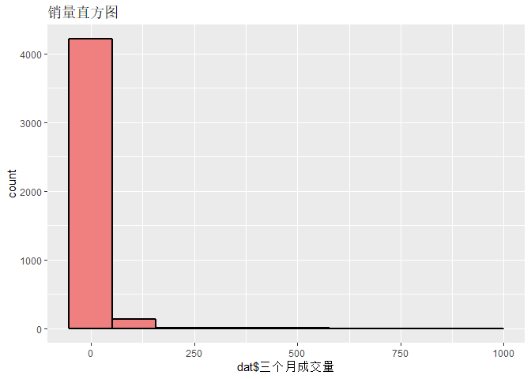

```r
library(ggplot2)
## 设置字体##
windowsFonts(kaiti=windowsFont('楷体'),zhongsong=windowsFont('华文中宋'))


## 画销量直方图##
p1<-ggplot(data=dat,mapping=aes(dat$三个月成交量))+
    geom_histogram(bins=10,fill='lightcoral',color='black',size=1)+#按照项目类型填充颜色
    ggtitle('销量直方图')
p1
```

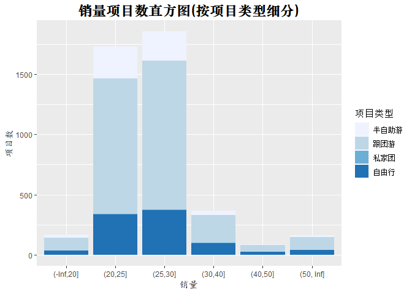

```r
##对销量进行分箱
dat$销量分箱<-cut(dat$三个月成交量,breaks=c(-Inf,20,25,30,40,50,Inf))

## 画分箱后的销量直方图（按项目类型分）
p<-ggplot(data=dat,mapping=aes(x=dat$销量分箱,fill=项目类型))+
   geom_bar(stat = 'count')+#按照项目类型填充颜色
  labs(x='销量',y='项目数')+#更改坐标轴名字
  ggtitle('销量项目数直方图(按项目类型细分)')+
  scale_fill_brewer()+
  theme(axis.title.x=element_text(family='kaiti'),axis.title.y=element_text(   family='kaiti'),plot.title = element_text(family='zhongsong',face='bold',size=rel(1.5),hjust = 0.5))
p
```

### 销量和行程长度

由于销量具有明显的右偏性，故在画图的时候考虑设置一个合理的值域再画图。不妨设置值域为15-40.

从箱线图中可以看出，短期旅行的销量高于中期，高于长期。图中的白点为箱线图的均值，也可以看出短期旅行的销量平均值明显高于中期和长期，但是中位数大小在图中不是很能体现，这说明短期旅行中有销量特别高的异常值。大致可以得到行程越短，销量越高的趋势。

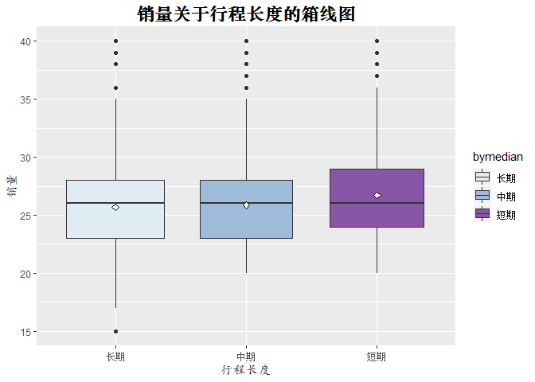

```r
#按照成交量中位数对行程长度进行排序##
bymedian<-with(dat,reorder(factor(dat$行程长度),dat$三个月成交量,FUN=median,na.rm=T))
##画箱线图##
p<-ggplot(dat,mapping =aes(x=bymedian,y=dat$三个月成交量,fill=bymedian))+
  geom_boxplot(varwidth=TRUE)+ #使箱线图的宽度反映数据量的大小
  labs(x='行程长度',y='销量',title='销量关于行程长度的箱线图')+
  ylim(15,40)+
  theme(axis.title.x=element_text(family='kaiti'),axis.title.y=element_text(   family='kaiti'),plot.title =   element_text(family='zhongsong',face='bold',size=rel(1.5),hjust = 0.5))+
  stat_summary(fun.y = mean,geom='point',shape=23,fill='white',size=2)+#标出平均值的位置
  scale_fill_brewer(palette = 'BuPu')
p
```

### 行程长度和项目类型

从项目数量的角度来看，长期项目和短期项目个数差不多，中期项目的个数最少。

如果按照项目类型分，跟团游的项目中长期项目最多，短期其次，中期最少；自由行的项目中，短期最多，中期次之，长期最少；半自助游项目中则是长期最多，短期最少。私家团只在长期项目和中期项目中有出现，中期项目比长期项目要多。私家团可以看作是自由行的推广，一般都是几户人家一起自由行便可以称作私家团。

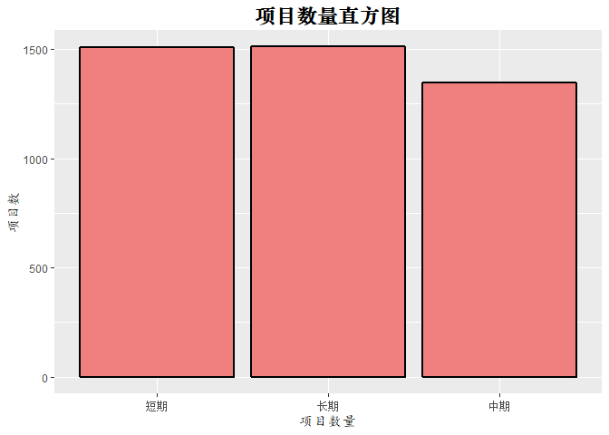

```r
p1<-ggplot(data=dat,mapping=aes(x=dat$行程长度))+
   geom_bar(stat = 'count',fill='lightcoral',color='black',size=1)+#填充颜色
  labs(x='项目数量',y='项目数')+#更改坐标轴名字
  ggtitle('项目数量直方图')+
  theme(axis.title.x=element_text(family='kaiti'),axis.title.y=element_text(   family='kaiti'),plot.title = element_text(family='zhongsong',face='bold',size=rel(1.5),hjust = 0.5))
p1
```

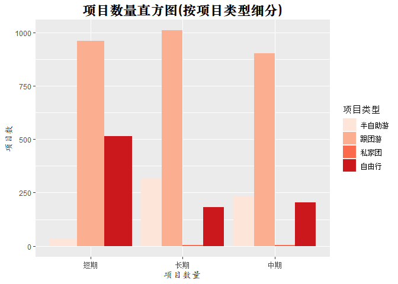

```r
p<-ggplot(data=dat,mapping=aes(x=dat$行程长度,fill=项目类型))+
   geom_bar(stat = 'count',position='dodge')+#按照项目类型填充颜色
  labs(x='项目数量',y='项目数')+#更改坐标轴名字
  ggtitle('项目数量直方图(按项目类型细分)')+
  scale_fill_brewer(palette='Reds')+
  theme(axis.title.x=element_text(family='kaiti'),axis.title.y=element_text(   family='kaiti'),plot.title = element_text(family='zhongsong',face='bold',size=rel(1.5),hjust = 0.5))
p
```

### 项目价格

项目价格也呈现右偏的趋势，因此将项目价格取对数之后画直方图，发现大部分项目的价格都在$e^5-e^{10}$之间。

根据销量分箱和项目价格的箱线图，可以看到随着销量增大，价格中位数和均值（小白点）有下降的趋势，故可以得到这样的初步结论，即销量高的项目，价格一般偏低。

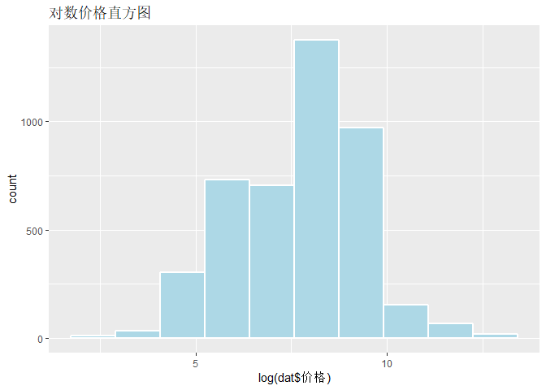

```r
##价格的分布##
p1<-ggplot(data=dat,mapping=aes(log(dat$价格)))+
    geom_histogram(bins=10,fill='lightblue',color='white',size=1)+#按照项目类型填充颜色
    ggtitle('对数价格直方图')
p1
```

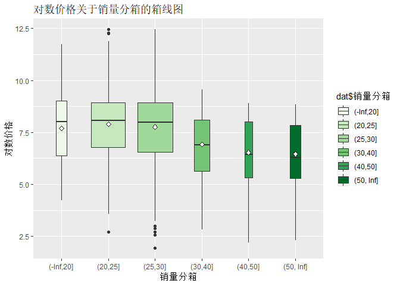

```r
##价格和销量##
p<-ggplot(dat,mapping =aes(x=dat$销量分箱,y=log(dat$价格),fill=dat$销量分箱))+
  geom_boxplot(varwidth=TRUE)+ #使箱线图的宽度反映数据量的大小
  labs(x='销量分箱',y='对数价格',title='对数价格关于销量分箱的箱线图')+
  stat_summary(fun.y = mean,geom='point',shape=23,fill='white',size=2)+
  scale_fill_brewer(palette='YiGn')
p
```

### 销量和目的地（旅游类型）的关系

我们可以对每个目的地进行销量分析，即对每个不同的目的地取销量均值，发现目的地是‘八达岭长城’的销量最高，远高于其他地方，其他国内的目的地例如长沙、颐和园等平均销量也很高。所以可以考虑把北京周边的目的地合并成一个变量，把其他国内省份合成一个变量。发现这就是旅游类型.

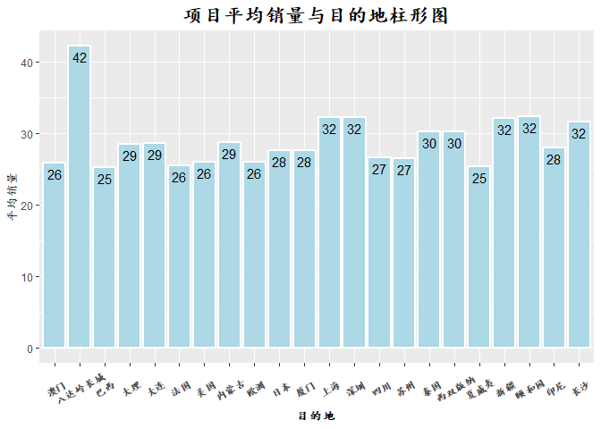

```r
##目的地##
desmean<-ddply(dat,'目的地',summarise,平均销量=mean(三个月成交量))

p<-ggplot(data=desmean,mapping=aes(x=desmean$目的地,y=desmean$平均销量))+
   geom_bar(stat = 'identity',fill='lightblue',color='white',size=1)+
  labs(x='目的地',y='平均销量')+#更改坐标轴名字
  ggtitle('项目平均销量与目的地柱形图')+
  geom_text(aes(label=round(desmean$平均销量)),vjust=1.5)+
  theme(axis.text.x = element_text(face='bold',size=rel(0.9),angle = 30,family='kaiti',vjust=0.5),plot.title = element_text(face='bold',size=rel(1.5),hjust =0.5,family="kaiti"),axis.title = element_text(face='bold',size=rel(0.9),family='kaiti'))
p
```

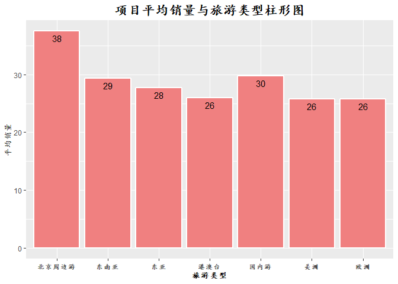

```r
##旅游类型##
desmean1<-ddply(dat,'旅游类型',summarise,平均销量=mean(三个月成交量))

p<-ggplot(data=desmean1,mapping=aes(x=desmean1$旅游类型,y=desmean1$平均销量))+
   geom_bar(stat = 'identity',fill='lightcoral',color='white',size=1)+
  labs(x='旅游类型',y='平均销量')+#更改坐标轴名字
  ggtitle('项目平均销量与旅游类型柱形图')+
  geom_text(aes(label=round(desmean1$平均销量)),vjust=1.5)+
  theme(axis.text.x = element_text(face='bold',size=rel(0.9),
  family='kaiti',vjust=0.5),plot.title = element_text(face='bold',size=rel(1.5),hjust =0.5,family="kaiti"),axis.title = element_text(face='bold',size=rel(0.9),family='kaiti'))
p
```

## 建立回归模型

由于三个月成交量是明显的右偏趋势，所以可以使用对数线性模型来建立销量和自变量的模型,由于成交量中有一些是0，这样会导致取了log之后是负数，故不妨重新设一列y。

经过分析，发现价格这一连续变量存在较严重的异方差现象，所以考虑建立加权回归模型。在建立全模型之后，发现调整过的R方比较小，可能是因为有些不显著的变量混在里面，导致原本显著的变量也变得不显著了，因此用逐步回归法对变量进行选择。

经过AIC和BIC两种准则的比较之后，发现两者的调整R方差别不太大，但是我们的目的是为了给在线旅游业的发展提供尽可能多的建议，所以希望显著的因子多一些比较好，故在这里选用AIC模型。

通过库克距离删除强影响点，然后再重新建立模型，用DAAG包进行变量共线性的诊断，发现除了自由行、跟团游之外，其他的vif值都小于10,而由于这两者是因子型变量的水平，所以无需去除。

```r
##重新设置一列y##
dat$y<-rep(0,n)
dat$y[dat$三个月成交量>0]<-log(dat$三个月成交量[dat$三个月成交量>0])
##建立加权全模型##
fit<-lm(y~性价比+飞机+酒店+景点数+规模+当日可定+出行保障+随时退+如实描述+无购物+无自费+铁定成团+项目类型+会员价+早订优惠+专享红包+优惠信息+多人立减+礼品卡+景点个数+行程长度+价格+旅游类型+factor(信用评级)+用户评价数量+factor(商家评级)+满意度+天数,data=dat,weight=1/价格)
summary(fit)
```

```
##
## Call:
## lm(formula = y ~ 性价比 + 飞机 + 酒店 + 景点数 + 规模 + 当日可定 +
##     出行保障 + 随时退 + 如实描述 + 无购物 + 无自费 + 铁定成团 +
##     项目类型 + 会员价 + 早订优惠 + 专享红包 + 优惠信息 + 多人立减 +
##     礼品卡 + 景点个数 + 行程长度 + 价格 + 旅游类型 + factor(信用评级) +
##     用户评价数量 + factor(商家评级) + 满意度 + 天数, data = dat,
##     weights = 1/价格)
##
## Weighted Residuals:
##      Min       1Q   Median       3Q      Max
## -0.35171 -0.00240  0.00008  0.00281  0.24782
##
## Coefficients: (1 not defined because of singularities)
##                       Estimate Std. Error t value Pr(>|t|)
## (Intercept)          2.647e+01  1.387e+00  19.083  < 2e-16 ***
## 性价比               6.067e-03  9.795e-04   6.195 6.39e-10 ***
## 飞机TRUE             1.003e-01  4.666e-02   2.150 0.031629 *
## 酒店3星             -6.679e-02  2.453e-02  -2.723 0.006504 **
## 酒店4星             -6.231e-02  2.988e-02  -2.085 0.037118 *
## 酒店5星             -1.212e-02  3.496e-02  -0.347 0.728766
## 景点数               2.570e-03  4.823e-03   0.533 0.594192
## 规模                 8.263e-04  3.758e-04   2.199 0.027930 *
## 当日可定TRUE        -1.661e-01  2.917e-02  -5.695 1.32e-08 ***
## 出行保障TRUE        -5.554e-02  2.777e-02  -2.000 0.045549 *
## 随时退TRUE           1.947e-02  1.860e-02   1.047 0.295150
## 如实描述TRUE         9.239e-02  2.896e-02   3.191 0.001429 **
## 无购物TRUE           8.013e-02  2.087e-02   3.840 0.000125 ***
## 无自费TRUE           1.775e-02  2.190e-02   0.811 0.417607
## 铁定成团TRUE         1.141e-02  2.225e-02   0.513 0.608162
## 项目类型跟团游      -2.756e-02  4.629e-02  -0.595 0.551622
## 项目类型私家团       2.050e-02  4.340e-01   0.047 0.962323
## 项目类型自由行       2.021e-01  7.249e-02   2.787 0.005336 **
## 会员价TRUE           1.168e+00  1.814e-01   6.438 1.34e-10 ***
## 早订优惠TRUE         1.113e+00  1.049e-01  10.608  < 2e-16 ***
## 专享红包TRUE                NA         NA      NA       NA
## 优惠信息TRUE         1.690e-01  8.123e-02   2.080 0.037548 *
## 多人立减TRUE        -6.880e-02  1.389e-01  -0.495 0.620305
## 礼品卡TRUE           6.389e-02  4.421e-02   1.445 0.148536
## 景点个数多           1.453e-02  7.883e-02   0.184 0.853797
```

[output cut: 13 more lines]

```
## factor(信用评级)3    6.804e-02  2.858e-02   2.380 0.017340 *
## factor(信用评级)4   -3.966e-02  2.268e-02  -1.749 0.080425 .
## factor(信用评级)5   -7.503e-02  2.160e-02  -3.474 0.000518 ***
## 用户评价数量         1.763e-03  4.846e-05  36.376  < 2e-16 ***
## factor(商家评级)4.9  2.412e-01  7.414e-02   3.254 0.001148 **
## factor(商家评级)5    1.762e-01  7.088e-02   2.486 0.012974 *
## 满意度              -2.362e-01  1.382e-02 -17.092  < 2e-16 ***
## 天数                -1.113e-02  1.322e-02  -0.842 0.399852
## ---
## Signif. codes:  0 '***' 0.001 '**' 0.01 '*' 0.05 '.' 0.1 ' ' 1
##
## Residual standard error: 0.01803 on 4320 degrees of freedom
##   (1 observation deleted due to missingness)
## Multiple R-squared:  0.4583, Adjusted R-squared:  0.4528
## F-statistic: 83.06 on 44 and 4320 DF,  p-value: < 2.2e-16
```

```r
##使用逐步回归法##
fit.aic<-step(fit,direction='both',trace=F)#AIC模型
summary(fit.aic)
```

```
##
## Call:
## lm(formula = y ~ 性价比 + 飞机 + 酒店 + 规模 + 当日可定 + 出行保障 +
##     如实描述 + 无购物 + 项目类型 + 会员价 + 早订优惠 + 优惠信息 +
##     礼品卡 + 旅游类型 + factor(信用评级) + 用户评价数量 + factor(商家评级) +
##     满意度 + 天数, data = dat, weights = 1/价格)
##
## Weighted Residuals:
##      Min       1Q   Median       3Q      Max
## -0.35045 -0.00240  0.00004  0.00282  0.24868
##
## Coefficients:
##                       Estimate Std. Error t value Pr(>|t|)
## (Intercept)          2.645e+01  1.376e+00  19.214  < 2e-16 ***
## 性价比               6.199e-03  9.589e-04   6.465 1.13e-10 ***
## 飞机TRUE             7.833e-02  4.228e-02   1.853 0.063992 .
## 酒店3星             -5.884e-02  2.363e-02  -2.490 0.012801 *
## 酒店4星             -5.500e-02  2.950e-02  -1.865 0.062313 .
## 酒店5星             -7.372e-03  3.472e-02  -0.212 0.831873
## 规模                 7.075e-04  3.622e-04   1.953 0.050827 .
## 当日可定TRUE        -1.631e-01  2.893e-02  -5.638 1.83e-08 ***
## 出行保障TRUE        -5.981e-02  2.737e-02  -2.185 0.028919 *
## 如实描述TRUE         1.042e-01  2.622e-02   3.975 7.15e-05 ***
## 无购物TRUE           9.054e-02  1.863e-02   4.859 1.22e-06 ***
## 项目类型跟团游      -2.035e-02  4.479e-02  -0.454 0.649663
## 项目类型私家团       3.373e-02  4.337e-01   0.078 0.938012
## 项目类型自由行       1.889e-01  4.946e-02   3.819 0.000136 ***
## 会员价TRUE           1.152e+00  1.810e-01   6.364 2.17e-10 ***
## 早订优惠TRUE         1.114e+00  1.038e-01  10.737  < 2e-16 ***
## 优惠信息TRUE         1.681e-01  8.089e-02   2.078 0.037783 *
## 礼品卡TRUE           7.438e-02  3.737e-02   1.990 0.046612 *
## 旅游类型东南亚      -5.599e-02  4.371e-02  -1.281 0.200239
## 旅游类型东亚         2.237e-01  8.011e-02   2.793 0.005247 **
## 旅游类型港澳台      -1.261e-01  3.921e-02  -3.217 0.001305 **
## 旅游类型国内游      -9.503e-02  1.894e-02  -5.017 5.45e-07 ***
## 旅游类型美洲         5.880e-02  8.777e-02   0.670 0.502922
## 旅游类型欧洲         2.699e-02  9.824e-02   0.275 0.783559
## factor(信用评级)1    8.485e-03  3.391e-02   0.250 0.802401
## factor(信用评级)2    3.884e-02  2.644e-02   1.469 0.141913
## factor(信用评级)3    6.789e-02  2.810e-02   2.416 0.015721 *
## factor(信用评级)4   -4.242e-02  2.232e-02  -1.901 0.057370 .
## factor(信用评级)5   -7.483e-02  2.138e-02  -3.500 0.000470 ***
## 用户评价数量         1.772e-03  4.803e-05  36.881  < 2e-16 ***
## factor(商家评级)4.9  2.442e-01  7.365e-02   3.316 0.000922 ***
## factor(商家评级)5    1.802e-01  6.997e-02   2.575 0.010052 *
## 满意度              -2.359e-01  1.375e-02 -17.161  < 2e-16 ***
## 天数                -1.373e-02  7.470e-03  -1.838 0.066204 .
## ---
## Signif. codes:  0 '***' 0.001 '**' 0.01 '*' 0.05 '.' 0.1 ' ' 1
##
## Residual standard error: 0.01803 on 4331 degrees of freedom
##   (1 observation deleted due to missingness)
## Multiple R-squared:  0.4571, Adjusted R-squared:  0.4529
## F-statistic: 110.5 on 33 and 4331 DF,  p-value: < 2.2e-16
```

```r
fit.bic<-step(fit,direction='both',k=log(n),trace=F)#BIC模型
summary(fit.bic)
```

```
##
## Call:
## lm(formula = y ~ 性价比 + 当日可定 + 如实描述 + 无购物 + 项目类型 +
##     会员价 + 早订优惠 + 用户评价数量 + factor(商家评级) + 满意度,
##     data = dat, weights = 1/价格)
##
## Weighted Residuals:
##      Min       1Q   Median       3Q      Max
## -0.35786 -0.00203  0.00020  0.00222  0.25481
##
## Coefficients:
##                       Estimate Std. Error t value Pr(>|t|)
## (Intercept)          2.584e+01  1.358e+00  19.036  < 2e-16 ***
## 性价比               4.848e-03  7.840e-04   6.183 6.85e-10 ***
## 当日可定TRUE        -1.817e-01  2.729e-02  -6.656 3.15e-11 ***
## 如实描述TRUE         1.226e-01  2.295e-02   5.340 9.75e-08 ***
## 无购物TRUE           9.937e-02  1.769e-02   5.617 2.07e-08 ***
## 项目类型跟团游       8.665e-03  4.259e-02   0.203 0.838805
## 项目类型私家团       1.005e-02  4.375e-01   0.023 0.981669
## 项目类型自由行       1.633e-01  4.437e-02   3.680 0.000236 ***
## 会员价TRUE           1.135e+00  1.814e-01   6.260 4.22e-10 ***
## 早订优惠TRUE         1.150e+00  1.040e-01  11.057  < 2e-16 ***
## 用户评价数量         1.805e-03  4.718e-05  38.261  < 2e-16 ***
## factor(商家评级)4.9  2.064e-01  6.537e-02   3.157 0.001607 **
## factor(商家评级)5    1.322e-01  6.329e-02   2.089 0.036801 *
## 满意度              -2.299e-01  1.359e-02 -16.923  < 2e-16 ***
## ---
## Signif. codes:  0 '***' 0.001 '**' 0.01 '*' 0.05 '.' 0.1 ' ' 1
##
## Residual standard error: 0.0182 on 4351 degrees of freedom
##   (1 observation deleted due to missingness)
## Multiple R-squared:  0.4437, Adjusted R-squared:  0.4421
## F-statistic:   267 on 13 and 4351 DF,  p-value: < 2.2e-16
```

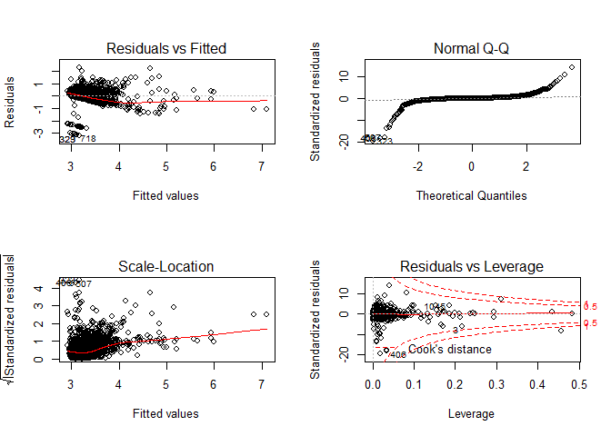

```r
##进行回归诊断##
par(mfrow=c(2,2))
plot(fit.aic)
```

```r
##通过库克距离找出强影响点，将其删除##
cook<-cooks.distance(fit.aic)
cook[cook>0.1]
```

```
##         3        94       282       323       406       482       485
## 0.3183347 0.2450370 0.7306020 0.2188095 0.3575886 0.1618395 1.8064906
##       488       499       507      1045
## 0.2409871 0.3080581 0.3247655 0.1095893
```

```r
dat<-dat[-c(3,94,282,323,406,482,485,488,499,507,1045),]
##重新建立回归模型##
fit<-lm(y~性价比+飞机+酒店+景点数+规模+当日可定+出行保障+随时退+如实描述+无购物+无自费+铁定成团+项目类型+会员价+早订优惠+专享红包+优惠信息+多人立减+礼品卡+景点个数+行程长度+价格+旅游类型+factor(信用评级)+用户评价数量+factor(商家评级)+满意度+天数,data=dat,weight=1/价格)
fit.aic<-step(fit,direction='both',trace=F)#AIC模型
summary(fit.aic)
```

```
##
## Call:
## lm(formula = y ~ 性价比 + 飞机 + 酒店 + 景点数 + 规模 + 当日可定 +
##     随时退 + 无购物 + 无自费 + 铁定成团 + 项目类型 + 会员价 +
##     早订优惠 + 优惠信息 + 礼品卡 + 旅游类型 + factor(信用评级) +
##     用户评价数量 + 满意度 + 天数, data = dat, weights = 1/价格)
##
## Weighted Residuals:
##       Min        1Q    Median        3Q       Max
## -0.250677 -0.002247  0.000062  0.002600  0.137445
##
## Coefficients:
##                     Estimate Std. Error t value Pr(>|t|)
## (Intercept)       20.5887594  1.0945027  18.811  < 2e-16 ***
## 性价比             0.0030248  0.0008325   3.633 0.000283 ***
## 飞机TRUE           0.0520713  0.0332386   1.567 0.117283
## 酒店3星           -0.0613961  0.0186898  -3.285 0.001028 **
## 酒店4星           -0.0762155  0.0232693  -3.275 0.001064 **
## 酒店5星           -0.0046381  0.0271561  -0.171 0.864393
## 景点数             0.0035253  0.0022879   1.541 0.123432
## 规模               0.0006130  0.0002800   2.189 0.028649 *
## 当日可定TRUE      -0.0866866  0.0253993  -3.413 0.000649 ***
## 随时退TRUE         0.0325367  0.0135774   2.396 0.016600 *
## 无购物TRUE         0.0474324  0.0159939   2.966 0.003037 **
## 无自费TRUE        -0.0304015  0.0172565  -1.762 0.078183 .
## 铁定成团TRUE       0.0378324  0.0170218   2.223 0.026295 *
## 项目类型跟团游    -0.0169564  0.0362352  -0.468 0.639841
## 项目类型私家团     0.0153561  0.3408730   0.045 0.964070
## 项目类型自由行     0.1099120  0.0397847   2.763 0.005757 **
## 会员价TRUE         0.8193330  0.1564314   5.238 1.70e-07 ***
## 早订优惠TRUE       1.0805397  0.0822095  13.144  < 2e-16 ***
## 优惠信息TRUE       0.0856605  0.0607507   1.410 0.158602
## 礼品卡TRUE         0.1164589  0.0277299   4.200 2.73e-05 ***
## 旅游类型东南亚    -0.0113550  0.0356975  -0.318 0.750433
## 旅游类型东亚       0.2486571  0.0636072   3.909 9.40e-05 ***
## 旅游类型港澳台    -0.0573879  0.0322594  -1.779 0.075318 .
## 旅游类型国内游    -0.0665664  0.0155973  -4.268 2.02e-05 ***
## 旅游类型美洲       0.1229505  0.0696685   1.765 0.077669 .
## 旅游类型欧洲       0.0694915  0.0778150   0.893 0.371889
## factor(信用评级)1 -0.0455404  0.0266600  -1.708 0.087673 .
## factor(信用评级)2 -0.0567786  0.0206052  -2.756 0.005884 **
## factor(信用评级)3 -0.0253991  0.0225586  -1.126 0.260264
## factor(信用评级)4 -0.0465315  0.0176986  -2.629 0.008591 **
## factor(信用评级)5 -0.1183130  0.0160932  -7.352 2.33e-13 ***
## 用户评价数量       0.0026011  0.0000647  40.201  < 2e-16 ***
## 满意度            -0.1749325  0.0109172 -16.024  < 2e-16 ***
## 天数              -0.0194347  0.0068627  -2.832 0.004648 **
## ---
## Signif. codes:  0 '***' 0.001 '**' 0.01 '*' 0.05 '.' 0.1 ' ' 1
##
## Residual standard error: 0.01417 on 4320 degrees of freedom
##   (1 observation deleted due to missingness)
## Multiple R-squared:  0.4561, Adjusted R-squared:  0.4519
## F-statistic: 109.8 on 33 and 4320 DF,  p-value: < 2.2e-16
```

```r
##进行变量共线性的诊断##
library(DAAG)
vif(fit.aic)
```

```
##            性价比          飞机TRUE           酒店3星           酒店4星
##            3.6038            2.8017            1.4411            1.3191
##           酒店5星            景点数              规模      当日可定TRUE
##            1.1988            2.3881            1.8883            2.9646
##        随时退TRUE        无购物TRUE        无自费TRUE      铁定成团TRUE
##            1.5177            2.1031            1.4883            2.6496
##    项目类型跟团游    项目类型私家团    项目类型自由行        会员价TRUE
##           11.9930            1.0114           14.2070            1.0286
##      早订优惠TRUE      优惠信息TRUE        礼品卡TRUE    旅游类型东南亚
##            1.0481            1.0276            1.6692            1.5733
##      旅游类型东亚    旅游类型港澳台    旅游类型国内游      旅游类型美洲
##            1.1766            1.9732            1.9307            1.1746
##      旅游类型欧洲 factor(信用评级)1 factor(信用评级)2 factor(信用评级)3
##            1.3442            1.1881            1.2283            1.2495
## factor(信用评级)4 factor(信用评级)5      用户评价数量            满意度
##            1.6965            1.2962            1.1851            1.3187
##              天数
##            5.1930
```

## 回归模型结果的解释与在线旅游业发展建议

在众多的变量中，回归模型最终剩下的解释变量可以认为是影响在线旅游产品销量的主要隐私，更进一步的，可以按照显著程度可以分成以下几类

- 非常显著: 截距项，性价比,有会员价,有早定优惠,支持礼品卡支付，旅游类型，信用评级，用户评价数量，满意度.
- 比较显著: 天数、保证铁定成团、无购物、随时退、当日可定、商店的规模、酒店类型、项目类型
- 勉强显著: 飞机出行、景点数、无自费项目

按照变量的实际含义，可以分别对变量的含义做出解释。  
在控制其他因素不变的情况下:  
从产品本身内容和特色来说，

- 行程天数每增加一天，项目的销量下降1.9% 说明短期项目的销量相对来说比长期项目要高，可能因为短期项目购买地更频繁。
- 景点个数每增加一个，销量增加0.3% 景点个数增加一定程度上意味着旅行项目的充实程度增加。
- 坐飞机比不做飞机的项目销量高5.2% 做飞机往往比做大巴有更高的舒适度。
- 从旅行的目的地来看，东南亚的项目比北京周边游的销量低1%，港澳台的项目比北京周边游的销量低5.7%，国内游的项目比北京周边游的项目低6.7%,东亚的项目比北京周边游的销量高24.9%，欧洲的项目比北京周边游高6.9%，每周的项目比北京周边游高12.3%。说明现在越来越多的人喜欢到较远的地区游玩，不再满足于国内长期游玩。
- 从项目类型来看，跟团游的销量比半自助游低1.7%，私家团的销量比半自助游高1.5%，自由行的销量比半自助游高11%。说明越来越多得人想自己探索出行，变得更加自主，而不是一味地听旅行团的摆布。
- 从酒店来看，住3星酒店的项目销量比住经济型酒店的项目销量低6.1%,4星酒店的比经济酒店的低7.6%,5星酒店的销量比经济酒店的低0.5%. 这一定程度上说明出行者对酒店星级看中的程度不太高，只要能接受就行。

从用户反馈的角度来说,

- 用户评价数量每增加一条，项目的期望销量就增加0.3%。说明用户的评价数可以带来成交量，同时成交量的增加又可以促进评价数量的增多，这是一个正反馈的过程。
- 用户满意度每提高一分，项目期望销量就剑豪17.5%。这可能是由于有些项目成交量过少导致零星的几个人就有100%好评，也可能是因为有些商家找人刷好评（好评返现）而造成的后果。

从产品的价格促销角度来说，

- 产品的性价比越高，项目的期望销量就越高。产品的性价比每增加一个单位，项目的期望销量就增加0.3%
- 项目有会员价促销的比没有会员价促销的销量期望高81.9%
- 项目有早订优惠促销的比没有的销量期望高108.1%
- 项目有礼品卡促销的比没有的销量期望高11.6%
- 项目有优惠信息促销的比没有的销量期望高8.6%.

因此，综合显著变量和上面的解释，可以提出这样的建议：

- 商家为了增大销量，可以努力提高自己产品的性价比，提供更多的消费者剩余价值，相对压缩自己的利润空间
- 商家可以选择更多样的促销服务，如支持礼品卡支付、提供早定优惠、为会员提供更优质的服务等来提高销量。
- 商家可以商家可以多推出一些自由行、半自由行等项目的比例，减少跟团游的比例，增多去较发达国家的游玩项目比例，适当减少国内游玩的项目比例，优化项目结构
- 商家可以努力扩大自己项目数量，推陈出新，扩大规模
- 商家可以努力提高自己的信用评级，早日脱离1-5星的范畴
- 商家不要盲目地追求五星好评，应该鼓励顾客多评论，实事求是的文字评价对销量的提高有更大的影响

```r
summary(fit.aic)
```

```
##
## Call:
## lm(formula = y ~ 性价比 + 飞机 + 酒店 + 景点数 + 规模 + 当日可定 +
##     随时退 + 无购物 + 无自费 + 铁定成团 + 项目类型 + 会员价 +
##     早订优惠 + 优惠信息 + 礼品卡 + 旅游类型 + factor(信用评级) +
##     用户评价数量 + 满意度 + 天数, data = dat, weights = 1/价格)
##
## Weighted Residuals:
##       Min        1Q    Median        3Q       Max
## -0.250677 -0.002247  0.000062  0.002600  0.137445
##
## Coefficients:
##                     Estimate Std. Error t value Pr(>|t|)
## (Intercept)       20.5887594  1.0945027  18.811  < 2e-16 ***
## 性价比             0.0030248  0.0008325   3.633 0.000283 ***
## 飞机TRUE           0.0520713  0.0332386   1.567 0.117283
## 酒店3星           -0.0613961  0.0186898  -3.285 0.001028 **
## 酒店4星           -0.0762155  0.0232693  -3.275 0.001064 **
## 酒店5星           -0.0046381  0.0271561  -0.171 0.864393
## 景点数             0.0035253  0.0022879   1.541 0.123432
## 规模               0.0006130  0.0002800   2.189 0.028649 *
## 当日可定TRUE      -0.0866866  0.0253993  -3.413 0.000649 ***
## 随时退TRUE         0.0325367  0.0135774   2.396 0.016600 *
## 无购物TRUE         0.0474324  0.0159939   2.966 0.003037 **
## 无自费TRUE        -0.0304015  0.0172565  -1.762 0.078183 .
## 铁定成团TRUE       0.0378324  0.0170218   2.223 0.026295 *
## 项目类型跟团游    -0.0169564  0.0362352  -0.468 0.639841
## 项目类型私家团     0.0153561  0.3408730   0.045 0.964070
## 项目类型自由行     0.1099120  0.0397847   2.763 0.005757 **
## 会员价TRUE         0.8193330  0.1564314   5.238 1.70e-07 ***
## 早订优惠TRUE       1.0805397  0.0822095  13.144  < 2e-16 ***
## 优惠信息TRUE       0.0856605  0.0607507   1.410 0.158602
## 礼品卡TRUE         0.1164589  0.0277299   4.200 2.73e-05 ***
## 旅游类型东南亚    -0.0113550  0.0356975  -0.318 0.750433
## 旅游类型东亚       0.2486571  0.0636072   3.909 9.40e-05 ***
## 旅游类型港澳台    -0.0573879  0.0322594  -1.779 0.075318 .
## 旅游类型国内游    -0.0665664  0.0155973  -4.268 2.02e-05 ***
## 旅游类型美洲       0.1229505  0.0696685   1.765 0.077669 .
## 旅游类型欧洲       0.0694915  0.0778150   0.893 0.371889
## factor(信用评级)1 -0.0455404  0.0266600  -1.708 0.087673 .
## factor(信用评级)2 -0.0567786  0.0206052  -2.756 0.005884 **
## factor(信用评级)3 -0.0253991  0.0225586  -1.126 0.260264
## factor(信用评级)4 -0.0465315  0.0176986  -2.629 0.008591 **
## factor(信用评级)5 -0.1183130  0.0160932  -7.352 2.33e-13 ***
## 用户评价数量       0.0026011  0.0000647  40.201  < 2e-16 ***
## 满意度            -0.1749325  0.0109172 -16.024  < 2e-16 ***
## 天数              -0.0194347  0.0068627  -2.832 0.004648 **
## ---
## Signif. codes:  0 '***' 0.001 '**' 0.01 '*' 0.05 '.' 0.1 ' ' 1
##
## Residual standard error: 0.01417 on 4320 degrees of freedom
##   (1 observation deleted due to missingness)
## Multiple R-squared:  0.4561, Adjusted R-squared:  0.4519
## F-statistic: 109.8 on 33 and 4320 DF,  p-value: < 2.2e-16
```